# Galamsey event study — Q1 (part 2): upstream mining → downstream vegetation (dCDH continuous dose)

Sree Ayyar, Till Meissner

09 Juli 2026

This is **Q1 part 2**: the **dCDH continuous-dose robustness** for the same design as `a_05_event_study_2.Rmd` (Q1 part 1, the Callaway & Sant’Anna mbar sweep). It was split out of that file **2026-07-09** because `did_multiplegt_dyn` runs on polars (Rust) and exhausted memory (`memory allocation … failed`) when chained after the ~80 C&S bootstrap fits in a single session at 2 km. Running it as its own document gives it a clean R process, and the `dcdh-fit` chunk below hands polars **only the five columns each fit needs** (not the full ~80-column panel) — the two changes that make the full battery fit in memory **at 2 km**.

**Estimator.** de Chaisemartin & D’Haultfœuille `did_multiplegt_dyn` treats each exposure’s mining **stock** as a continuous treatment intensity and estimates the effect of *changes in dose*, pooling across dose levels — a robustness check against Q1 part 1’s discretisation of the stock at $\bar m \in \{0, 5, 10, 20\}$ ha. One fit per **(routing × exposure × outcome)**:

- **Two directed exposures to start** (2026-07-09 simplification): **upstream 1-hop** (treatment) vs **downstream 1-hop** (placebo) — the cleanest treatment-vs-placebo contrast, and few enough fits (2 × 2 × 2 = 8) to stay under polars’ memory ceiling at 2 km. The other three exposures (all-reachable upstream, lateral, all-reachable downstream) are commented out in `exposure-spec`; re-add them once this runs cleanly.
- **Two routing cut-offs:** ROUTE_KM2 = 10 (primary, unsuffixed columns) and ROUTE_KM2 = 50 (`_upa50`, robustness) — see `event_study_design.md`.
- **Two outcomes:** EVI peak (annual max) over the `veg_narrow` and `no-mine-crop` masks.

SEs clustered on real HydroBASINS level-9 sub-basins (`basin_num`; falls back to a 25 km centroid-block stand-in if absent — see `load-panel`). Requires `DIDmultiplegtDYN` **and** `polars` installed (`HAS_DCDH = TRUE).

# 1 Data foundations

```r
es    <- readRDS(here("data", "processed", sprintf("event_panel_%dkm.rds", params$resolution_km)))
panel <- es$panel

# Spatial clustering key: real HydroBASINS level-9 sub-basins (basin_num) when present, else a 25 km
# centroid-block stand-in. Aliased onto block_num so the dCDH cluster arg needs one name only.
has_basin <- all(c("basin_id", "basin_num") %in% names(panel)) && !all(is.na(panel$basin_num))
if (has_basin) {
  panel <- panel |> mutate(block_num = basin_num)
  message(sprintf("Clustering on %d HydroBASINS level-9 sub-basins (basin_num).",
                  n_distinct(panel$block_num)))
} else {
  warning("basin_id/basin_num not found -- falling back to the 25 km centroid-block SE-clustering ",
          "stand-in. Run d_07_hydrobasins.R then b_03e_assemble_eventpanel.R for real clustering.")
  hex_sf <- es$hex_sf
  cent   <- sf::st_coordinates(suppressWarnings(sf::st_centroid(sf::st_geometry(hex_sf))))
  blocks <- tibble(hex_id = hex_sf$hex_id,
                   block_id = paste0("b_", round(cent[, 1] / 25000), "_", round(cent[, 2] / 25000)))
  panel  <- left_join(panel, blocks, by = "hex_id") |>
    mutate(block_num = as.integer(factor(block_id)))
}

has_upstream <- !all(is.na(panel$up_onset_year))
c(upstream_columns_present = has_upstream,
  hydrobasins_clustering   = has_basin,
  n_clusters               = n_distinct(panel$block_num))
```

```
## upstream_columns_present   hydrobasins_clustering               n_clusters
##                        1                        1                      287
```

```r
# EVI peak (annual max) over veg_narrow (headline) and no-mine-crop -- same restriction as Q1 part 1.
OUTCOMES <- c(
  evi_modis_veg_narrow_max = "EVI (peak, veg-narrow)",
  evi_modis_nominecrop_max = "EVI (peak, no-mine-crop)"
)
OUTCOMES <- OUTCOMES[names(OUTCOMES) %in% names(panel)]
OUTCOMES <- OUTCOMES[vapply(names(OUTCOMES), \(c) !all(is.na(panel[[c]])), logical(1))]
names(OUTCOMES)
```

```
## [1] "evi_modis_veg_narrow_max" "evi_modis_nominecrop_max"
```

## 1.1 Exposure definitions

```r
# SIMPLIFIED START (2026-07-09): begin with just the two 1-hop exposures — upstream 1-hop
# (treatment) vs downstream 1-hop (placebo), the cleanest treatment-vs-placebo contrast. This cuts
# the dCDH battery from 5x2x2 = 20 fits to 2x2x2 = 8, which — together with the callr subprocess
# isolation below — is what lets it survive polars' memory ceiling at 2 km. The other three exposures
# (up all-reachable, lateral, down all-reachable) are commented out; re-add rows to expand once this
# runs. Each is flow-graph-derived, so each has a "_upa50" (ROUTE_KM2 = 50) sibling.
EXPOSURES <- tibble::tribble(
  ~key,      ~stock,                  ~label,                       ~role,
  "near_up", "nearest_up_stock_ha",   "upstream — 1-hop",           "treatment",
  "near_dn", "nearest_down_stock_ha", "downstream — 1-hop",         "placebo"
  # "up",   "up_stock_ha",           "upstream — all reachable",   "treatment",
  # "lat",  "lateral_stock_ha",      "lateral (off-flow)",         "comparison",
  # "dn",   "down_stock_ha",         "downstream — all reachable", "placebo"
)
role_lvls     <- c("treatment", "comparison", "placebo")
exposure_lvls <- EXPOSURES$label
exposure_cols <- c("upstream — all reachable"   = "#4292C6",
                   "upstream — 1-hop"           = "#08306B",
                   "lateral (off-flow)"         = "#238B45",
                   "downstream — 1-hop"         = "#D94701",
                   "downstream — all reachable" = "#FDAE6B")

ROUTINGS    <- c(upa10 = "", upa50 = "_upa50")
routing_lab <- c(upa10 = "ROUTE_KM2 = 10 (primary)", upa50 = "ROUTE_KM2 = 50 (robustness)")

resolve_exposures <- function(suffix) {
  EXPOSURES |>
    mutate(stock = paste0(stock, suffix), routing_suffix = suffix) |>
    filter(stock %in% names(panel),
           vapply(stock, \(c) !all(is.na(panel[[c]])), logical(1)))
}
ROUTINGS_OK <- ROUTINGS[vapply(ROUTINGS, \(s) nrow(resolve_exposures(s)) > 0, logical(1))]
tibble(routing     = names(ROUTINGS_OK),
       definition  = routing_lab[names(ROUTINGS_OK)],
       n_exposures = vapply(ROUTINGS_OK, \(s) nrow(resolve_exposures(s)), integer(1))) |>
  kbl(caption = "Routing cut-offs available in this panel and how many of the 5 exposures resolve.") |>
  kable_styling(full_width = FALSE)
```

| routing | definition | n_exposures |
| --- | --- | --- |
| upa10 | ROUTE_KM2 = 10 (primary) | 2 |
| upa50 | ROUTE_KM2 = 50 (robustness) | 2 |

# 2 dCDH continuous dose (`did_multiplegt_dyn`)

```r
if (!HAS_DCDH)
  cat("> **dCDH skipped** — `DIDmultiplegtDYN` and/or `polars` are not installed. ",
      "Install both to run the continuous-dose robustness check.\n")
```

```r
# MEMORY / PANIC ISOLATION (the reason for the split + subprocess). did_multiplegt_dyn ingests the
# WHOLE data frame into a polars (Rust) frame; on the ~632k-row 2 km panel this hits the machine's
# memory ceiling, and polars then *panics* (`called Result::unwrap() on an Err … memory allocation
# … failed`). A Rust panic is NOT an R error, so an in-process tryCatch can't catch it — it aborts
# the whole knit. Two defences:
#   1. Hand it ONLY the five columns a fit needs (group/time/cluster/outcome/treatment), not the
#      full ~80-column panel — a fraction of the RAM.
#   2. Run each fit in a FRESH R subprocess via callr::r(). A panic/OOM crashes only the child,
#      which callr reports back as a catchable error here; the child also releases all polars Rust
#      memory on exit, so nothing accumulates across the battery.
run_dcdh <- function(yname, treat_col) {
  d <- as.data.frame(panel[, c("hex_id", "year", "block_num", yname, treat_col)])
  # A constant (all-equal) treatment column makes did_multiplegt_dyn panic in polars — skip it.
  if (length(unique(d[[treat_col]])) < 2) {
    message("dCDH skipped (constant treatment): ", treat_col, " / ", yname); return(NULL)
  }
  tryCatch(
    callr::r(
      function(d, yname, treat_col) {
        library(polars)   # must be ATTACHED for DIDmultiplegtDYN 2.3.0's bare `pl` symbol
        m <- DIDmultiplegtDYN::did_multiplegt_dyn(
          df = d, outcome = yname, group = "hex_id", time = "year",
          treatment = treat_col, effects = 5, placebo = 3, cluster = "block_num", graph_off = TRUE)
        list(results = m$results)
      },
      args = list(d = d, yname = yname, treat_col = treat_col)),
    error = function(e) { message("dCDH failed (", treat_col, ", ", yname, "): ",
                                  conditionMessage(e)); NULL })
}

dcdh_fits <- list()
for (rt in names(ROUTINGS_OK)) {
  ex <- resolve_exposures(ROUTINGS_OK[[rt]])
  for (i in seq_len(nrow(ex))) for (oc in names(OUTCOMES)) {
    key <- paste(rt, ex$key[i], oc, sep = "|")
    fit <- run_dcdh(oc, ex$stock[i])
    if (!is.null(fit)) dcdh_fits[[key]] <- list(
      fit = fit, routing = rt, exposure = ex$label[i], role = ex$role[i],
      outcome = oc, outcome_lab = OUTCOMES[[oc]], key = ex$key[i])
  }
}
c(dcdh_fits_kept = length(dcdh_fits))
```

```
## dcdh_fits_kept
##              8
```

## 2.1 Event-time plots

```r
# dCDH convention: Effect_l -> event time +l (post), Placebo_l -> -l (pre), reference at 0.
tidy_dcdh <- function(obj) {
  mk <- function(mat, sgn) {
    if (is.null(mat) || !nrow(mat)) return(NULL)
    tibble(event_time = sgn * seq_len(nrow(mat)),
           est = mat[, "Estimate"], lo = mat[, "LB CI"], hi = mat[, "UB CI"])
  }
  bind_rows(mk(obj$results$Effects, 1L), mk(obj$results$Placebos, -1L),
            tibble(event_time = 0L, est = 0, lo = NA_real_, hi = NA_real_)) |>
    arrange(event_time)
}

for (rt in names(ROUTINGS_OK)) {
  cat(sprintf("\n\n### %s\n\n", routing_lab[rt]))
  for (oc in names(OUTCOMES)) {
    cat(sprintf("\n\n#### %s\n\n", OUTCOMES[[oc]]))
    for (k in EXPOSURES$key) {
      key <- paste(rt, k, oc, sep = "|")
      if (is.null(dcdh_fits[[key]])) next
      meta <- dcdh_fits[[key]]
      d    <- tidy_dcdh(meta$fit)
      col  <- if (meta$exposure %in% names(exposure_cols)) exposure_cols[[meta$exposure]] else "#721F81"
      p <- ggplot(d, aes(event_time, est)) +
        geom_hline(yintercept = 0, linetype = "dashed", colour = "grey50") +
        geom_vline(xintercept = -0.5, linetype = "dotted", colour = "grey40") +
        geom_line(colour = col) + geom_point(colour = col, size = 1.9) +
        geom_errorbar(aes(ymin = lo, ymax = hi), width = 0.18, colour = col) +
        scale_x_continuous(breaks = sort(unique(d$event_time))) +
        labs(title = sprintf("dCDH — %s stock → %s", meta$exposure, OUTCOMES[[oc]]),
             subtitle = sprintf("Continuous-dose (stock) estimator; %s (%s); 95%% CI",
                                routing_lab[rt], meta$role),
             x = "Event time (years relative to stock-dose change)",
             y = paste0("Effect on ", OUTCOMES[[oc]])) +
        theme_bw(base_size = 11)
      print(p)
      save_es(p, sprintf("es_q1_dcdh_%s_%s_%s.png", rt, k, oc), height = 4.2)
    }
  }
}
```

### 2.1.1 ROUTE_KM2 = 10 (primary)

#### 2.1.1.1 EVI (peak, veg-narrow)

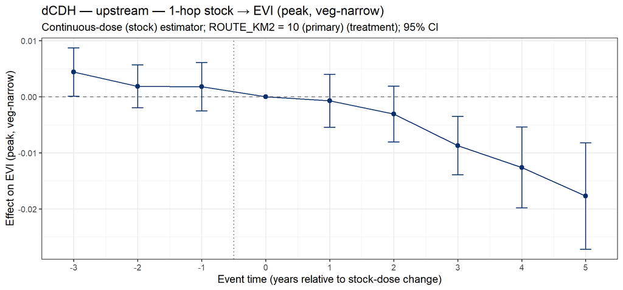

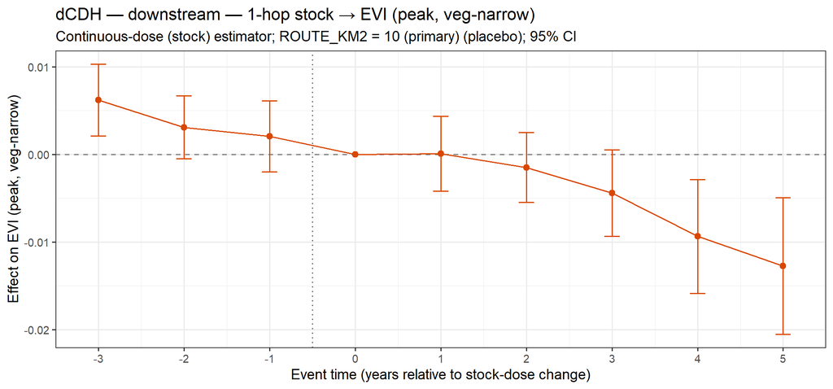

#### 2.1.1.2 EVI (peak, no-mine-crop)

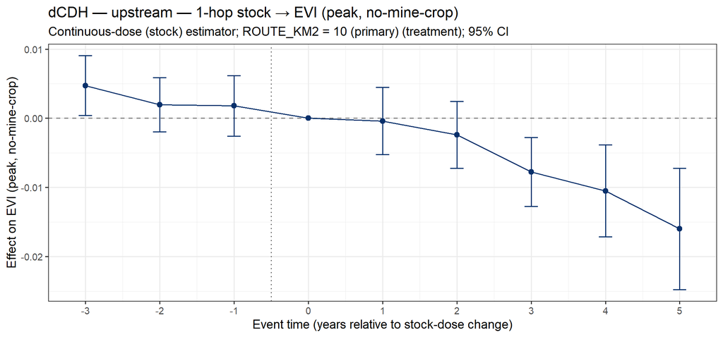

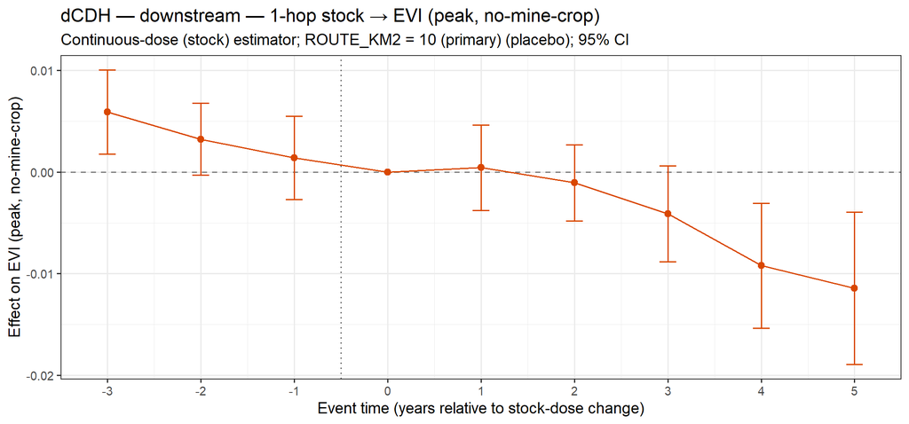

### 2.1.2 ROUTE_KM2 = 50 (robustness)

#### 2.1.2.1 EVI (peak, veg-narrow)

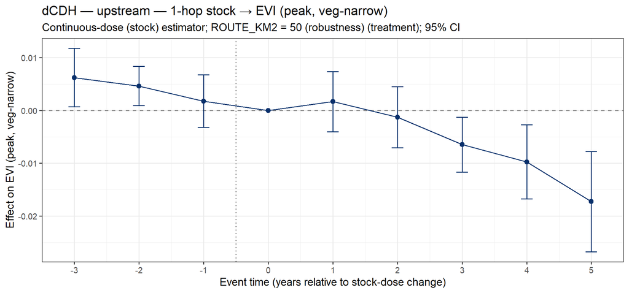

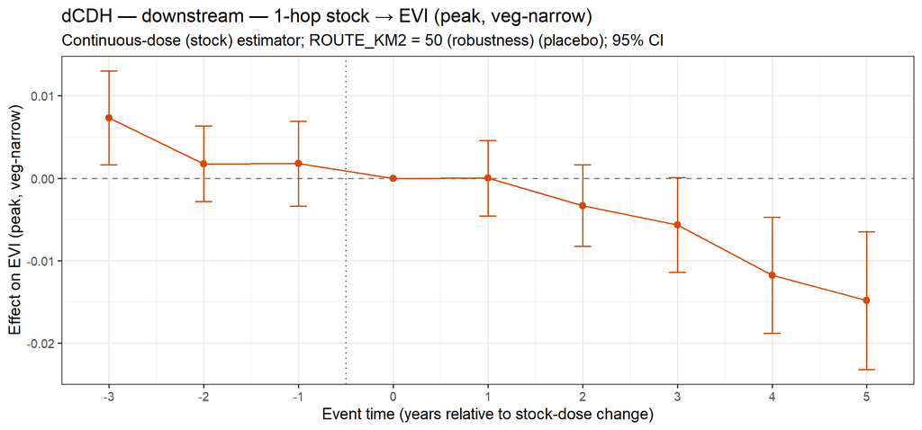

#### 2.1.2.2 EVI (peak, no-mine-crop)

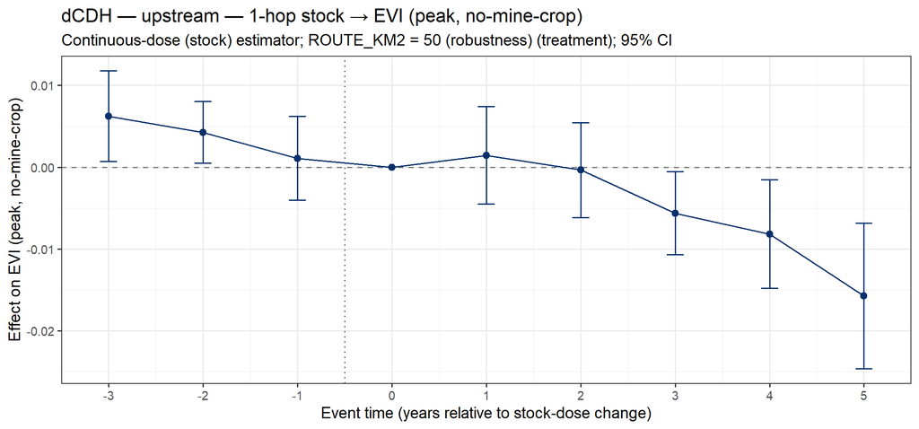

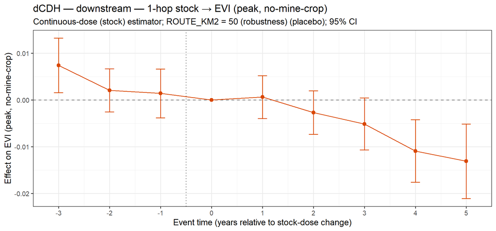

## 2.2 Summary table

```r
scl  <- function(x) if (is.null(x)) NA_real_ else as.numeric(x)
pick <- function(a, col) if (is.matrix(a)) a[1, col] else a[[col]]
dcdh_summary <- function(obj) {
  a <- obj$results$ATE
  tibble(ate = pick(a, "Estimate"), ci_lo = pick(a, "LB CI"), ci_hi = pick(a, "UB CI"),
         p_pre = scl(obj$results$p_jointplacebo), p_effects = scl(obj$results$p_jointeffects),
         switchers = pick(a, "Switchers"))
}

dcdh_tab <- bind_rows(lapply(dcdh_fits, \(m)
  dcdh_summary(m$fit) |> mutate(routing = routing_lab[m$routing], role = m$role,
                                exposure = m$exposure, outcome = m$outcome_lab, .before = 1))) |>
  mutate(`ATE [95% CI]` = sprintf("%.4f [%.4f, %.4f]", ate, ci_lo, ci_hi),
         `p(pre-trend)` = sprintf("%.3f", p_pre),
         `p(effects)`   = sprintf("%.3f", p_effects)) |>
  arrange(routing, outcome, factor(role, levels = role_lvls),
          factor(exposure, levels = exposure_lvls))

save_md(dcdh_tab |> select(routing, outcome, exposure, `ATE [95% CI]`,
                           `p(pre-trend)`, `p(effects)`, switchers),
        "es_q1_dcdh_summary.md")
dcdh_tab |>
  select(routing, outcome, exposure, `ATE [95% CI]`, `p(pre-trend)`, `p(effects)`, switchers) |>
  kbl(caption = paste0(
    "dCDH summary (continuous exposure-stock dose). ATE = average total effect on EVI; ",
    "p(pre-trend) = joint placebo test (high = pre-trends flat, design credible); ",
    "p(effects) = joint test that dynamic effects are zero; Switchers = hexes identifying the ATE.")) |>
  kable_styling(full_width = FALSE)
```

dCDH summary (continuous exposure-stock dose). ATE = average total effect on EVI; p(pre-trend) = joint placebo test (high = pre-trends flat, design credible); p(effects) = joint test that dynamic effects are zero; Switchers = hexes identifying the ATE.

| routing | outcome | exposure | ATE [95% CI] | p(pre-trend) | p(effects) | switchers |
| --- | --- | --- | --- | --- | --- | --- |
| ROUTE_KM2 = 10 (primary) | EVI (peak, no-mine-crop) | upstream — 1-hop | -0.0014 [-0.0024, -0.0005] | 0.158 | 0.002 | 4775 |
| ROUTE_KM2 = 10 (primary) | EVI (peak, no-mine-crop) | downstream — 1-hop | -0.0010 [-0.0018, -0.0001] | 0.029 | 0.012 | 6415 |
| ROUTE_KM2 = 10 (primary) | EVI (peak, veg-narrow) | upstream — 1-hop | -0.0016 [-0.0026, -0.0007] | 0.227 | 0.001 | 4725 |
| ROUTE_KM2 = 10 (primary) | EVI (peak, veg-narrow) | downstream — 1-hop | -0.0011 [-0.0019, -0.0002] | 0.026 | 0.014 | 6375 |
| ROUTE_KM2 = 50 (robustness) | EVI (peak, no-mine-crop) | upstream — 1-hop | -0.0011 [-0.0019, -0.0002] | 0.034 | 0.001 | 3315 |
| ROUTE_KM2 = 50 (robustness) | EVI (peak, no-mine-crop) | downstream — 1-hop | -0.0012 [-0.0020, -0.0003] | 0.096 | 0.010 | 3880 |
| ROUTE_KM2 = 50 (robustness) | EVI (peak, veg-narrow) | upstream — 1-hop | -0.0012 [-0.0021, -0.0003] | 0.042 | 0.001 | 3295 |
| ROUTE_KM2 = 50 (robustness) | EVI (peak, veg-narrow) | downstream — 1-hop | -0.0013 [-0.0022, -0.0004] | 0.084 | 0.006 | 3865 |

# 3 Static exports

```r
tibble(file = list.files(out_es, pattern = "es_q1_dcdh.*\\.(png|md)$")) |>
  mutate(kind = ifelse(grepl("\\.png$", file), "figure", "table")) |>
  arrange(kind, file) |>
  kbl(caption = "dCDH static outputs written to outputs/figures/event_study/.") |>
  kable_styling(full_width = FALSE)
```

dCDH static outputs written to outputs/figures/event_study/.

| file | kind |
| --- | --- |
| es_q1_dcdh_upa10_near_dn_evi_modis_nominecrop_max.png | figure |
| es_q1_dcdh_upa10_near_dn_evi_modis_veg_narrow_max.png | figure |
| es_q1_dcdh_upa10_near_up_evi_modis_nominecrop_max.png | figure |
| es_q1_dcdh_upa10_near_up_evi_modis_veg_narrow_max.png | figure |
| es_q1_dcdh_upa50_near_dn_evi_modis_nominecrop_max.png | figure |
| es_q1_dcdh_upa50_near_dn_evi_modis_veg_narrow_max.png | figure |
| es_q1_dcdh_upa50_near_up_evi_modis_nominecrop_max.png | figure |
| es_q1_dcdh_upa50_near_up_evi_modis_veg_narrow_max.png | figure |
| es_q1_dcdh_summary.md | table |

# 4 Caveats & next steps